# Statistische Modellierung mit R

Ein Workshop für die PH Zürich

Veröffentlichungsdatum

17. Oktober 2025

# Methodology: The Science before Statistics

Jede statistische Modellierung gewinnt an Aussagekraft, je umfassender sie die inhaltliche Fragestellung abzubilden im Stande ist. Um aus der riesigen Fülle an Optionen geeignet und zielgerichtet auswählen zu können sind die folgenden Unterscheidungen hilfreich.

## Erkenntnisinteressen

Ganz grundlegend kann a priori das Erkenntnisinteresse von Studien in die folgenden vier Kategorien unterschieden werden:

Erkenntisinteressen nach (Döring und Bortz 2016).

| Deskriptiv | Explorativ | Explanativ | Prädiktiv |
| --- | --- | --- | --- |
| populationsbeschreibend | hypothesengenerierend | hypothesenprüfend | Datenpunkte vorhersagend oder imputierend |
| *Bei welchem Anteil 15-Jähriger in Deutschland handelt es sich um funktionale Analphabet:innen?* | *Was sind potentielle Ursachen für genderbezogene Disparitäten im Analphabetismus?* | *Sind 15-jährige Jungen häufiger Analphabeten als 15-jährige Mädchen?* | *Mit welchen Variablen können Schüler:innen at risk erfolgreich identifiziert werden?* |

## Gütekriterien wiss. Erkenntnis nach Campbell (1957)

Für ein erfolgreiches Studiendesign und die anschließende statistische Analyse ist es sehr wertvoll sich vorab über Schwerpunkte besonders gewünschter Aspekte wissenschaftlicher Güte Gedanken zu machen. Insbesondere über die Unterkriterien **Methodischer Strenge**

- **Konstruktvalidität** (*Inwiefern ist die Interpretation der Messwerte angemessen?*)
- **Interne Validität** (*Inwiefern sind Assoziationen von unabhängiger [beeinflussender] und abhängiger [beeinflusster] Variabler als kausale Effekte interpretierbar?*)
- **Externe Validität** (*Inwiefern können die Schlussfolgerungen der Studie verallgemeinert werden?*)
- **Statistische Validität** (*Wie robust und angemessen sind die verwendeten statistischen Verfahren?*)

## Deskriptiv- und Inferenzstatistik

**Deskriptive Statistik** beschreibt vorliegende Daten (z.B. Effektstärken), während **Inferenzstatistik** Aussagen über den die Daten generierenden Mechanismus trifft. Beide können »eher einfach« oder »hoch komplex« sein und oftmals sethen sie in einem synergetischen Verhältnis (siehe Abbildung 1).

[figure not shown]

Abbildung 1: Verhältnis von deskriptiver und Inferenzstatistik”

## Bayesianisches und Frequentistisches Schätzen und Testen

Eine sehr heuristische Klassifikation inferenzstatistischer Verfahren stellt die Unterscheidung von statistischer Schätzung und Testung:

> (Inferenzstatistische) *Schätzungen* (estimation with quantified uncertainty) treffen anhand von Stichproben Aussagen über Parameter der Grundgesamtheit (Population) aus der die Stichprobe gezogen wurde.[^1]

<sup>1</sup> Bspw.: *Mit 96%er Wahrscheinlichkeit liegt die Analphabetismusinzidienz von 15-Jährigen in Deutschland zwischen .08 und .12*

> (Inferenzstatistische) *Hypothesentests* bewerten anhand von Stichprobendaten die Gültigkeit von Hypothesen in der Grundgesamtheit (Population) aus der die Stichprobe gezogen wurde.[^2]

<sup>2</sup> Bspw.: *Nimmt man an, dass sich die Analphabetismusinzidienz von 15-Jährigen in Deutschland zwischen 2021 und 2025 nicht geändert hat beträgt die Wahrscheinlichkeit der vorliegenden Daten p = .032*

Diese beiden Verfahren können sowohl im Rahmen der **frequentistischen Statistik** als auch der **bayesianischen Statistik** angewendet werden. Die folgende Tabelle gibt einen Überblick über die wichtigsten Werkzeuge:

|  | Frequentistische Statistik | Bayesianische Statistik |
| --- | --- | --- |
| Parameterschätzung | Konfidenzintervalle | Posterior Distributions |
| Hypothesentest | p-Werte | Bayes Faktoren & ROPE Procedure |

## Hypothesenarten

Bayesianische wie frequentistischen Hypothesentests können unterschiedliche Arten von Hypothesen zugrunde gelegt werden:

- **Punkthypothesen** setzen Parameter gleich einer reellen Zahl; etwa $H_0\text{: } \delta = 0$
- **Äquivalenzhypothesen** nehmen Parameter in einem reellen Intervall an; etwa $H_0\text{: } \delta \not\in\ [-.3, .3]$
- **Informative Hypothesen** nehmen eine Ordnungsrelation mehrerer Parameter an; etwa $\mu_{\text{Baseline}} < \mu_{\text{Imaginary Pill}} < \mu_{\text{Blinded Placebo}}$ (Buergler u. a. 2023)

> **Die *Art* der (falsifizierten) Hypothese entscheidet wesentlich stärker über den Informationsgehalt eines Hypothesentests als die Entscheidung für das frequentistische oder bayesianische Paradigma** (Hoijtink 2012).

Dies ist am leichtest anhand der Nullhypothese nachvollziehbar. Wird etwa die Nullhypothese $H_0\text{: } \delta = 0$ verworfen, wird entsprechend die Alternativhypothese $H_A\text{: } \delta \neq 0$ angenommen. Diese enthält aber quasi keine Information, da sie nur mit einer einzigen Beobachtung (d = 0.000000 …) verworfen werden kann und im kritischen Rationalismus gilt, dass eine Aussage umso mehr Information enthält, umso leichter sie verworfen werden kann (Döring und Bortz 2016).

Äquivalenzhypothesen können sowohl frequentistisch (z.B. TOAST-Prozedur in R und JASP, Lakens 2017) wie bayesianisch (z.B. ROPE-Ansatz Kruschke 2015) getestet werden. Für das Testen informativer Hypothesen liegen bayesianische Methoden in (u.a.) JASP und R vor (z.B. `{bain}`, Gu u. a. 2019) sowie in frequentistischen R-Paketen restriktor (Vanbrabant 2020) und ic.infer (Grömping 2010).

# Grundlagen der Regressionsanalyse

Regressionsanalysen sind ein sehr mächtiges Werkzeug um Zusammenhänge oder Unterschiede zwischen/in Variablen zu modellieren. Innerhalb der Regressionsanalyse kann sowohl geschätz als auch getestet werden und dies jeweils bayesianisch oder frequentistisch.

Die Grundidee der lineare Regression ist in [diesem interaktiven Applet](https://www.geogebra.org/m/wDpDdS7g) veranschaulicht. Eine Abhängige Variable $y_i$ wird also als normalverteilt mit bedingtem Erwartungswert $b_0 + b_1*x_i$ und $\sigma$ angenommen:

$$y_i \sim \mathcal{N}\left( b_0 + b_1*x_i, \sigma \right)$$

## Datengrundlage

Das wollen wir den berühmten Daten aus dem STAR-Experiment (Student/Teacher Achievement Ratio) illustrieren. In diesem Experiment wurden in Tennessee Schüler:innen zufällig auf Klassen mit kleiner (13-17 Schüler:innen pro Lehrer:in) und großer (22-25 Schüler:innen pro Lehrer:in) Klassengröße zugeteilt. Zusätzlich gab es Klassen großer Größe, die von einer:n ausgebildeten Hilfslehrer:in unterstützt wurde. Die Schüler:innen wurden über mehrere Jahre getestet.

Wir können die Daten [herunterladen](https://github.com/sammerk/Zuerich_Statistics/tree/master/data) oder direkt programmatisch importieren.

````markdown
```{r}
library(readr) # für den data import
library(dplyr)    # für das datawrangling
```
```{r}
data_star <-
  readr::read_csv(
    paste0(
      "https://raw.githubusercontent.com/sammerk/",
      "Zuerich_Statistics/master/data/star.csv"
    )
  )
```
````

Der Satzsatz sieht wie folgt aus:

````markdown
```{r}
glimpse(data_star)
```
````

```
Rows: 26,796
Columns: 18
$ id      <dbl> 100017, 100028, 100045, 100045, 100045, 100064, 100070, 100070…
$ sch     <dbl> 28, 52, 41, 41, 41, 64, 40, 40, 22, 22, 22, 17, 17, 3, 3, 3, 3…
$ gr      <chr> "K", "K", "1", "2", "3", "K", "K", "1", "K", "1", "2", "K", "1…
$ cltype  <chr> "small", "reg", "small", "small", "small", "small", "reg", "re…
$ hdeg    <chr> "BS/BA", "MS/MA/MEd", "BS/BA", "MS/MA/MEd", "BS/BA", "BS/BA", …
$ clad    <chr> "1", "1", "1", "APPR", "1", "1", "APPR", "1", "PROB", "1", "NO…
$ exp     <dbl> 3, 12, 20, 15, 5, 19, 2, 5, 9, 9, 2, 20, 16, 8, 23, 21, 14, 6,…
$ trace   <chr> "B", "W", "W", "B", "W", "W", "W", "W", "B", "B", "B", "W", "W…
$ read    <dbl> 476, 410, 507, 575, 610, 430, 495, 629, 418, 524, 627, 421, 45…
$ math    <dbl> 602, 444, 572, 620, 655, 484, 576, 592, 489, 567, 603, 459, 46…
$ ses     <chr> "F", "N", "N", "N", "N", "N", "F", "F", "F", "F", "F", "N", "N…
$ schtype <chr> "inner", "suburb", "suburb", "suburb", "suburb", "rural", "rur…
$ sx      <chr> "F", "F", "M", "M", "M", "F", "F", "F", "F", "F", "F", "M", "M…
$ eth     <chr> "B", "W", "W", "W", "W", "W", "W", "W", "B", "B", "B", "W", "W…
$ birthq  <chr> "1980:1", "1980:2", "1980:2", "1980:2", "1980:2", "1980:1", "1…
$ birthy  <dbl> 1980, 1980, 1980, 1980, 1980, 1980, 1979, 1979, 1980, 1980, 19…
$ yrs     <dbl> 0, 0, 1, 2, 3, 0, 0, 1, 0, 1, 2, 0, 1, 0, 2, 3, 0, 0, 0, 0, 1,…
$ tch     <dbl> 478, 893, 698, 701, 706, 1102, 679, 684, 351, 359, 365, 267, 2…
```

Die Variablen dieses Datensatzes sind die folgenden:

- `id`: a factor - student id number
- `sch`: a factor - school id number
- `gr`: grade - an ordered factor with levels K < 1 < 2 < 3
- `cltype`: class type - a factor with levels small, reg and reg+A. The last level indicates a regular class size with a teachers aide.
- `hdeg`: highest degree obtained by the teacher - an ordered factor with levels ASSOC < BS/BA < MS/MA/MEd < MA+ < Ed.S < Ed.D/Ph.D
- `clad`: career ladder position of the teacher - a factor with levels NOT APPR PROB PEND 1 2 3
- `exp`: a numeric vector - the total number of years of experience of the teacher
- `trace`: teacher’s race - a factor with levels W, B, A, H, I and O representing white, black, Asian, Hispanic, Indian (Native American) and other
- `read`: the student’s total reading scaled score
- `math`: the student’s total math scaled score
- `ses`: socioeconomic status - a factor with levels F and N representing eligible for free lunches or not eligible
- `schtype`: school type - a factor with levels inner, suburb, rural and urban
- `sx`: student’s sex - a factor with levels M F
- `eth`: student’s ethnicity - a factor with the same levels as trace
- `birthq`: student’s birth quarter - an ordered factor with levels 1977:1 < … < 1982:2
- `birthy`: student’s birth year - an ordered factor with levels 1977:1982
- `yrs`: number of years of schooling for the student - a numeric version of the grade gr with Kindergarten represented as 0. This variable was generated from gr and does not allow for a student being retained.
- `tch`: a factor - teacher id number

Um nicht gleich mit Mehrebenenregression starten zu müssen, erstellen wir als erstes einen Subdatensatz, der nur eine:n Schüler:in pro Lehrer:in enthält

````markdown
```{r}
data_star_sub <-
    data_star %>%
    group_by(tch) %>%
    sample_n(1) %>%
    ungroup()
```
````

## »Effekte« der Klassenstufe

### Einfache lineare Regression

Zunächst wollen wir »Effekte« der Klassenstufe modellieren. Ich empfehle dringend kosequent Daten erst zu visualisieren und dann statistisch zu modellieren.

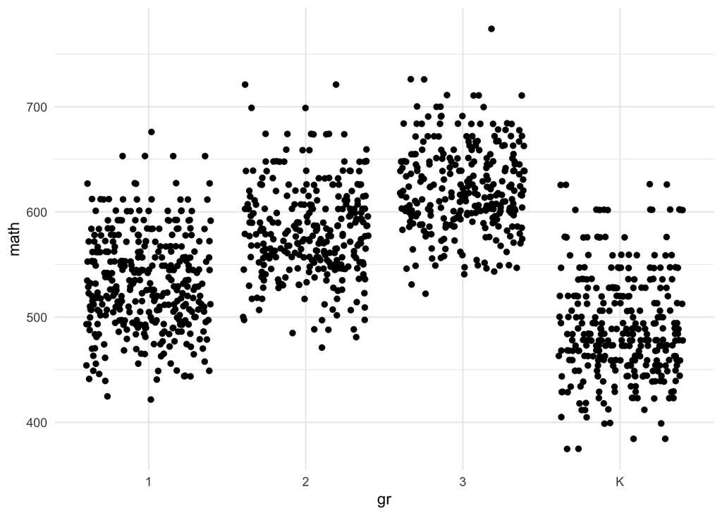

````markdown
```{r}
library(ggplot2)  # plots
```
```{r}
library(ggforce)  # sina plots

ggplot(data_star_sub, aes(gr, math)) +
    geom_jitter() +
    theme_minimal()
```
````

Die unabhängige Variable ist hier noch nicht intervallskaliert. Dies können wir wie folgt ändern.

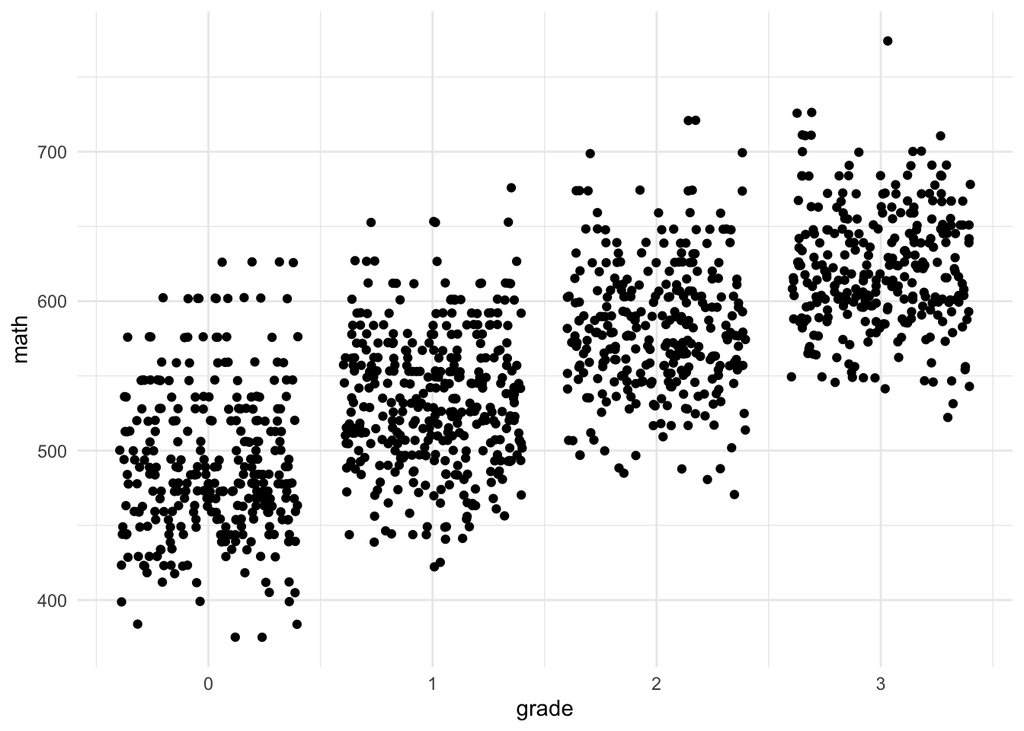

````markdown
```{r}
# Das Schuljahr K zu 0 rekodieren
data_star_sub <-
    data_star_sub %>%
    mutate(grade = case_when(gr == "K" ~ 0,
                                                     gr == "1" ~ 1,
                                                     gr == "2" ~ 2,
                                                     gr == "3" ~ 3
                                                     ))
# Anschließend nochmals visualisieren
ggplot(data_star_sub, aes(grade, math)) +
    geom_jitter() +
    theme_minimal()
```
````

Dann kann eine erste Regressionsgerade modelliert werden.

#### Frequentistische Punktschätzung

Mit der Funktion `lm()` werden mithilfe kleinster Quadrate $b_0$ und $b_1$ geschätzt.

````markdown
```{r}
mod0 <- lm(math ~ grade, data = data_star_sub)
mod0
```
````

```
Call:
lm(formula = math ~ grade, data = data_star_sub)

Coefficients:
(Intercept)        grade
     489.62        44.42
```

#### Frequentistischer Nullhypothesensignifikanztest

Die Standardinferenzstatistik zu einem solchen Modell ist sind p-Werte für die Nullhypothesen
$$H_0:\; b_0 = 0$$
$$H_0:\; b_1 = 0$$

````markdown
```{r}
summary(mod0)
```
````

```
Call:
lm(formula = math ~ grade, data = data_star_sub)

Residuals:
     Min       1Q   Median       3Q      Max
-114.617  -30.575   -5.033   28.448  151.136

Coefficients:
            Estimate Std. Error t value Pr(>|t|)
(Intercept)  489.617      2.115  231.45   <2e-16 ***
grade         44.416      1.162   38.23   <2e-16 ***
---
Signif. codes:  0 '***' 0.001 '**' 0.01 '*' 0.05 '.' 0.1 ' ' 1

Residual standard error: 45.08 on 1248 degrees of freedom
  (137 observations deleted due to missingness)
Multiple R-squared:  0.5394,    Adjusted R-squared:  0.539
F-statistic:  1462 on 1 and 1248 DF,  p-value: < 2.2e-16
```

#### Frequentistische Konfidenzintervalle

````markdown
```{r}
confint(mod0)
```
````

```
                2.5 %    97.5 %
(Intercept) 485.46664 493.76690
grade        42.13644  46.69509
```

#### Bayesianischer Posterior Distributions

````markdown
```{r}
library(MCMCpack) #für bayesianische Schätzung
```
````

[output not shown]

[output not shown]

[output not shown]

[output not shown]

```
Iterations = 1001:11000
Thinning interval = 1
Number of chains = 1
Sample size per chain = 10000

1. Empirical mean and standard deviation for each variable,
   plus standard error of the mean:

               Mean     SD Naive SE Time-series SE
(Intercept)  489.62  2.115  0.02115        0.02115
grade         44.41  1.175  0.01175        0.01175
sigma2      2036.07 81.708  0.81708        0.81708

2. Quantiles for each variable:

               2.5%     25%    50%     75%   97.5%
(Intercept)  485.47  488.19  489.6  491.05  493.78
grade         42.12   43.62   44.4   45.19   46.72
sigma2      1881.66 1979.85 2033.9 2090.40 2200.34
```

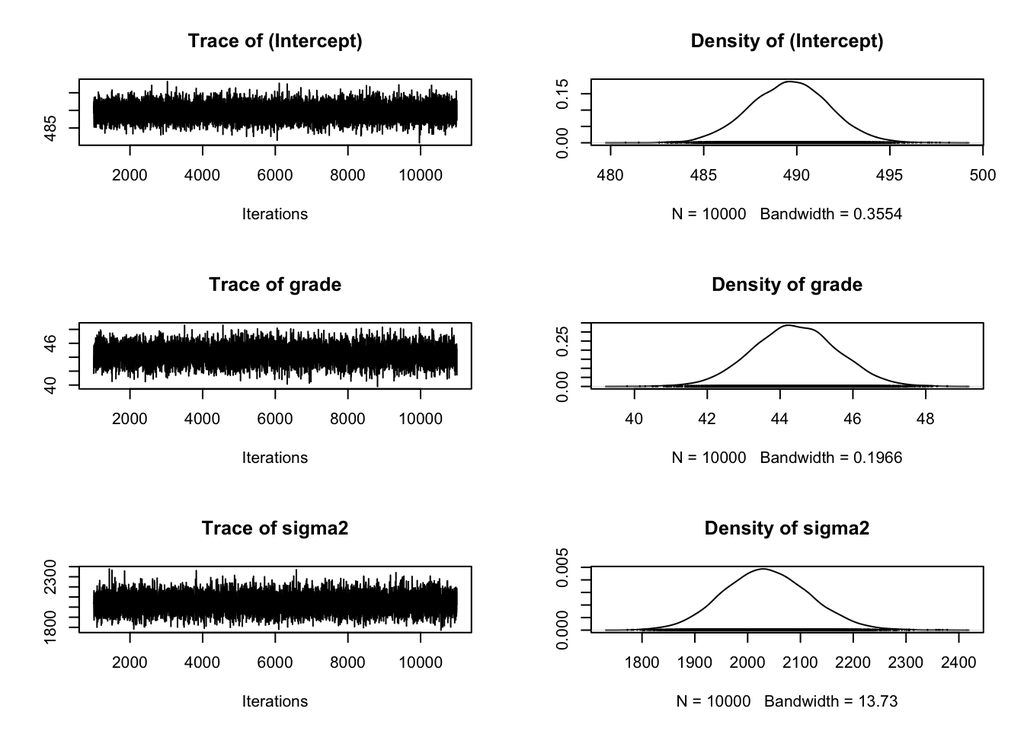

````markdown
```{r}
mod1 <- MCMCregress(math ~ grade, data = data_star_sub)

plot(mod1)
summary(mod1)
```
````

## Literatur

Buergler, Sarah, Dilan Sezer, Niels Bagge, Irving Kirsch, Cosima Locher, Claudia Carvalho, und Jens Gaab. 2023. „Imaginary Pills and Open-Label Placebos Can Reduce Test Anxiety by Means of Placebo Mechanisms Scientific Reports“. *Scientific Reports* 13 (1): 2624. https://doi.org/10.1038/s41598-023-29624-7.

Campbell, Donald T. 1957. „Factors Relevant to the Validity of Experiments in Social Settings“. *Psychological Bulletin* 54 (4): 297–312. https://doi.org/10.1037/h0040950.

Döring, Nicola, und Jürgen Bortz. 2016. *Forschungsmethoden und Evaluation in den Sozial- und Humanwissenschaften*. 5., vollst. Berlin, Heidelberg: Springer.

Grömping, Ulrike. 2010. „Inference with Linear Equality and Inequality Constraints Using R: The Package Ic.infer“. *Journal of Statistical Software* 33 (Februar): 1–31. https://doi.org/10.18637/jss.v033.i10.

Gu, Xin, Herbert Hoijtink, Joris Mulder, und Yves Rosseel. 2019. „Bain: A Program for Bayesian Testing of Order Constrained Hypotheses in Structural Equation Models“. *Journal of Statistical Computation and Simulation* 89 (8): 1526–53. https://doi.org/10.1080/00949655.2019.1590574.

Hoijtink, Herbert. 2012. *Informative Hypotheses: Theory and Practice for Behavioral and Social Scientists*. Chapman & Hall/CRC Statistics in the Social and Behavioral Sciences Series. Boca Raton: CRC.

Kruschke, John K. 2015. *Doing Bayesian Data Analysis: A Tutorial with R, JAGS, and Stan*. 2nd Aufl. Academic Press.

Lakens, Daniël. 2017. „Equivalence Tests: A Practical Primer for t Tests, Correlations, and Meta-Analyses“. *Social Psychological and Personality Science* 8 (4): 355–62. https://doi.org/10.1177/1948550617697177.

Vanbrabant, L. 2020. *Restriktor: Constrained Statistical Inference*. https://cran.r-project.org/package=restriktor.